# Projekt 2

Młyniec Paweł, Artur Godlewski

11/01/2021

Do zadania 1 przydzielonymi naszemu zespołowi są województwa: swietokrzyskie, zachodnio-pomorskie, podlaskie, mazowieckie, wielkopolskie, warminsko-mazurskie i malopolskie. Do zadania 1 przydzielonymi naszemu zespołowi są ligi: Primeira Liga (Liga portugalska), Ekstraklasa (Liga polska), Primera Division (Liga hiszpańska) i Premier League (Liga rosyjska).

```r
library(ggplot2, scales)
library(reshape)
options(warn=-1)
```

**Zadanie 1.** Korzystajac z danych dostepnych w internecie:

```r
z1Data = read.csv("data/z1Data.csv");
```

**a) Sprawdz, czy wirus SARS-CoV-2 równomiernie rozprzestrzenił sie na terenie Polski, tzn. czy liczba osób zarazonych wirusem w poszczególnych województwach jest proporcjonalna do populacji tych województw.**

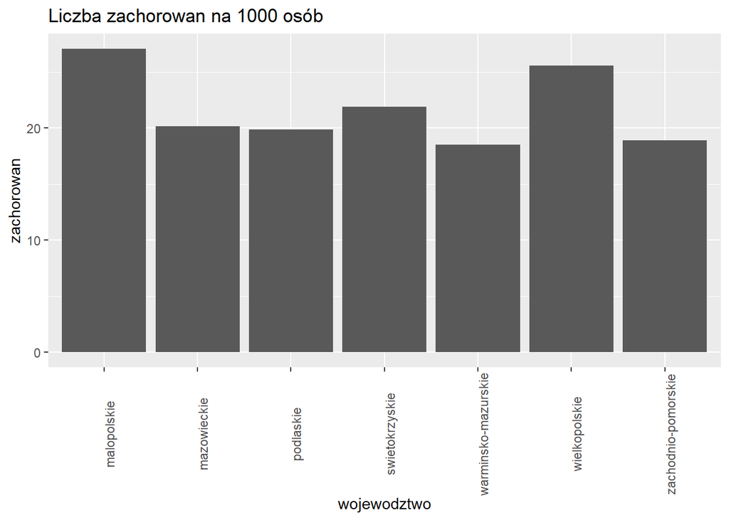

```r
df = z1Data[,c(1,3)];
df[,2] = 1000 * df[,2]/z1Data[,2];
ggplot(data=df, aes(x=wojewodztwo,y=zachorowan)) +
  geom_bar(stat = "identity") +
  ggtitle("Liczba zachorowań na 1000 osób") +
  theme(axis.text.x = element_text(angle = 90))
```

```r
h0 = "ilość zakażonych nie jest proporcjonalna do populacji województwa";
h1 = "ilość zakażonych jest proporcjonalna do populacji województwa";
```

Hipoteza zerowa: ilosc zakazonych nie jest proporcjonalna do populacji województwa  
Hipoteza alternatywna: ilosc zakazonych jest proporcjonalna do populacji województwa

```r
alpha = 0.05;
df = z1Data[c(2,3)];
df[1] = df[1] - df[2]
chisq = chisq.test(df);
p = chisq$p.value;
if(p > alpha){
  output = paste("Wartość p jest większa od alfy, więc hipoteza zerowa, że ", h0, ", została odrzucona. Przyjmujemy jako prawdziwą hipoteze alternatywną: ", h1, ".");
}else {
  output = paste("Wartość p jest mniejsza od alfy, więc hipoteza zerowa, że ", h0, ", została potwierdzona.");
}
```

Wartosc alfa jest rowna 0.05  
Wartość p jest równa 0  
Wartosc p jest mniejsza od alfy, wiec hipoteza zerowa, ze ilosc zakazonych nie jest proporcjonalna do populacji województwa , zostala potwierdzona.

```r
pairs = apply(z1Data, 2, combn, m=2);
pValues = list();

for(i in 1:nrow(pairs)){
  if(i%%2 == 1){
    df = data.frame(pairs[c(i,(i+1)), c(2:3)]);
    df[, c(1:2)] <- sapply(df[, c(1:2)], as.numeric)
    df[1] = df[1] - df[2];
    p = chisq.test(df)$p.value;
    pValues = append(pValues, p);
  }
}
output1 = ""
output2 = ""
pValues = p.adjust(pValues, method = "bonferroni")
for(i in 1:length(pValues)){
  if(pValues[i] < alpha){
    output1 = paste(output1, pairs[2*i-1,1], " i ", pairs[2*i,1], "z wartością p równą ", pValues[i], ",  \n")
  }else{
    output2 = paste(output2, pairs[2*i-1,1], " i ", pairs[2*i,1], "z wartością p równą ", pValues[i], ",  \n")
  }
}
```

Istotne różnice zostały znalezione dla następujących województw:  
swietokrzyskie i zachodnio-pomorskie z wartoscia p równa 1.10068038735977e-72 ,  
swietokrzyskie i podlaskie z wartoscia p równa 5.11991591144308e-28 ,  
swietokrzyskie i mazowieckie z wartoscia p równa 1.13597811728252e-34 ,  
swietokrzyskie i wielkopolskie z wartoscia p równa 6.25230230598263e-112 ,  
swietokrzyskie i warminsko-mazurskie z wartoscia p równa 5.91493614233895e-86 ,  
swietokrzyskie i malopolskie z wartoscia p równa 4.32366057347171e-213 ,  
zachodnio-pomorskie i podlaskie z wartoscia p równa 1.71564969887055e-07 ,  
zachodnio-pomorskie i mazowieckie z wartoscia p równa 5.0866894443827e-23 ,  
zachodnio-pomorskie i wielkopolskie z wartoscia p równa 0 ,  
zachodnio-pomorskie i malopolskie z wartoscia p równa 0 ,  
podlaskie i wielkopolskie z wartoscia p równa 3.69487074245968e-267 ,  
podlaskie i warminsko-mazurskie z wartoscia p równa 8.40194011539634e-14 ,  
podlaskie i malopolskie z wartoscia p równa 0 ,  
mazowieckie i wielkopolskie z wartoscia p równa 0 ,  
mazowieckie i warminsko-mazurskie z wartoscia p równa 1.83699256219407e-34 ,  
mazowieckie i malopolskie z wartoscia p równa 0 ,  
wielkopolskie i warminsko-mazurskie z wartoscia p równa 0 ,  
wielkopolskie i malopolskie z wartoscia p równa 4.18159120551261e-34 ,  
warminsko-mazurskie i malopolskie z wartoscia p równa 0 ,

Nie znaleziono istotnych różnic dla następujących województw:  
zachodnio-pomorskie i warminsko-mazurskie z wartoscia p równa 0.249700264991881 ,  
podlaskie i mazowieckie z wartoscia p równa 0.739947787754135 ,

**b) Sprawdz, czy skutecznosc leczenia osób zarazonych wirusem SARS-CoV-2 jest taka sama na terenie całej Polski, tzn. czy liczba przypadków smiertelnych jest proporcjonalna do liczby osób zarazonych przy podziale na województwa.**

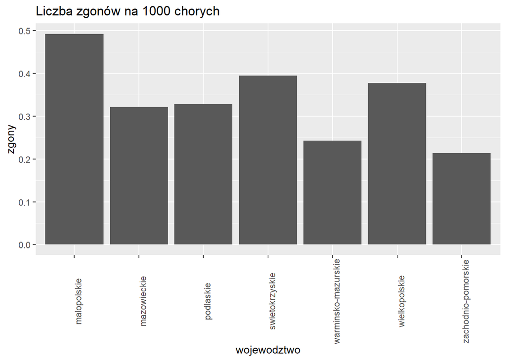

```r
df = z1Data[,c(1,4)];
df[,2] = 1000 * df[,2]/z1Data[,2];
ggplot(data=df, aes(x=wojewodztwo,y= zgony)) +
  geom_bar(stat = "identity") +
  ggtitle("Liczba zgonów na 1000 chorych") +
  theme(axis.text.x = element_text(angle = 90))
```

```r
h0 = "ilość przypadków śmiertelnych nie jest proporcjonalna do ilości osób zakażonych w województwie";
h1 = "ilość przypadków śmiertelnych jest proporcjonalna do ilości osób zakażonych w województwie";
```

Hipoteza zerowa: ilosc przypadków smiertelnych nie jest proporcjonalna do ilosci osób zakazonych w województwie  
Hipoteza alternatywna: ilosc przypadków smiertelnych jest proporcjonalna do ilosci osób zakazonych w województwie

```r
alpha = 0.05;
df = z1Data[c(3,4)];
df[1] = df[1] - df[2];
chisq = chisq.test(df);
p = chisq$p.value;
if(p > alpha){
  output = paste("Wartość p jest większa od alfy, więc hipoteza zerowa, że ", h0, ", została odrzucona. Przyjmujemy jako prawdziwą hipoteze alternatywną: ", h1, ".");
}else {
  output = paste("Wartość p jest mniejsza od alfy, więc hipoteza zerowa, że ", h0, ", została potwierdzona.");
}
```

[output not shown]

```r
pairs = apply(z1Data, 2, combn, m=2);
pValues = list();

for(i in 1:nrow(pairs)){
  if(i%%2 == 1){
    df = data.frame(pairs[c(i,(i+1)), c(3:4)]);
    df[, c(1:2)] <- sapply(df[, c(1:2)], as.numeric)
    df[1] = df[1] - df[2];
    p = chisq.test(df)$p.value;
    pValues = append(pValues, p);
  }
}
output1 = ""
output2 = ""
pValues = p.adjust(pValues, method = "bonferroni")
for(i in 1:length(pValues)){
  if(pValues[i] < alpha){
    output1 = paste(output1, pairs[2*i-1,1], " i ", pairs[2*i,1], "z wartością p równą ", pValues[i], ",  \n")
  }else{
    output2 = paste(output2, pairs[2*i-1,1], " i ", pairs[2*i,1], "z wartością p równą ", pValues[i], ",  \n")
  }
}
```

Istotne różnice zostały znalezione dla następujących województw:  
swietokrzyskie i zachodnio-pomorskie z wartoscia p równa 1.56580406550237e-10 ,  
swietokrzyskie i wielkopolskie z wartoscia p równa 0.0035129281598417 ,  
swietokrzyskie i warminsko-mazurskie z wartoscia p równa 9.57896563027689e-05 ,  
zachodnio-pomorskie i podlaskie z wartoscia p równa 2.95171408279173e-06 ,  
zachodnio-pomorskie i mazowieckie z wartoscia p równa 2.57917687313948e-08 ,  
zachodnio-pomorskie i wielkopolskie z wartoscia p równa 0.000105538619895294 ,  
zachodnio-pomorskie i malopolskie z wartoscia p równa 1.15393985713475e-15 ,  
podlaskie i warminsko-mazurskie z wartoscia p równa 0.0336219104352783 ,  
mazowieckie i warminsko-mazurskie z wartoscia p równa 0.0143574024120177 ,  
mazowieckie i malopolskie z wartoscia p równa 0.00312573846733098 ,  
wielkopolskie i malopolskie z wartoscia p równa 2.9456096352055e-07 ,  
warminsko-mazurskie i malopolskie z wartoscia p równa 3.72023780478054e-07 ,

Nie znaleziono istotnych różnic dla następujących województw:  
swietokrzyskie i podlaskie z wartoscia p równa 1 ,  
swietokrzyskie i mazowieckie z wartoscia p równa 0.40116121963892 ,  
swietokrzyskie i malopolskie z wartoscia p równa 1 ,  
zachodnio-pomorskie i warminsko-mazurskie z wartoscia p równa 1 ,  
podlaskie i mazowieckie z wartoscia p równa 1 ,  
podlaskie i wielkopolskie z wartoscia p równa 1 ,  
podlaskie i malopolskie z wartoscia p równa 1 ,  
mazowieckie i wielkopolskie z wartoscia p równa 0.688590727981941 ,  
wielkopolskie i warminsko-mazurskie z wartoscia p równa 0.971986177359949 ,

**2. Sprawdz teze mówiaca o tym, ze tzw. atut własnego boiska w ligowym meczu piłkarskim nie zalezy od kraju, w którym tocza sie dane rozgrywki ligowe. W tym celu, zweryfikuj hipoteze o niezaleznosci wyniku meczu, rozumianego jako zwyciestwo, porazke lub remis gospodarzy, od kraju rozgrywek.**

W ramach rozwiazania zadania zaimplementuj odpowiednie dla testu niezaleznosci wyrazenia, na podstawie których obliczane sa: statystyka testowa, wartosc krytyczna oraz p-wartosc.

Przeprowadz wnioskowanie porównujac wartosc otrzymanej statystyki testowej z wartoscia krytyczna, przy poziomie istotnosci 0, 05. Czy obliczona p-wartosc potwierdza wynik wnioskowania? Sprawdz uzyskane wyniki wykorzystujac funkcje chisq.test.

Hipoteza zerowa
$$H0:\ _"Atut\ własnego\ boiska\ jest\ niezależny\ od\ ligi\ rozgrywkowej."$$
Hipoteza alternatywna
$$H1:\ _"Atut\ własnego\ boiska\ jest\ zależny\ od\ ligi\ rozgrywkowej."$$

Hipoteza będzie sprawdzana testem $\chi^{2}$.

Dane zostały zebrane z strony https://pl.fcstats.com.

Wczytanie danych:

```r
fc_data <- data.frame(Name = c("Primeria_Liga", "Ekstrakalasa", "Primera_Division", "Premier_League"),
                 Win= c(104, 108,194,109),
                 Draw=c(68, 65, 95,69),
                 Lost=c(68,67,91,62));

fc_data
```

```
##               Name Win Draw Lost
## 1    Primeria_Liga 104   68   68
## 2     Ekstrakalasa 108   65   67
## 3 Primera_Division 194   95   91
## 4   Premier_League 109   69   62
```

Wykresy obrazujące wygrane, remisy i porażki gospodarzy w poszczególnych ligach:

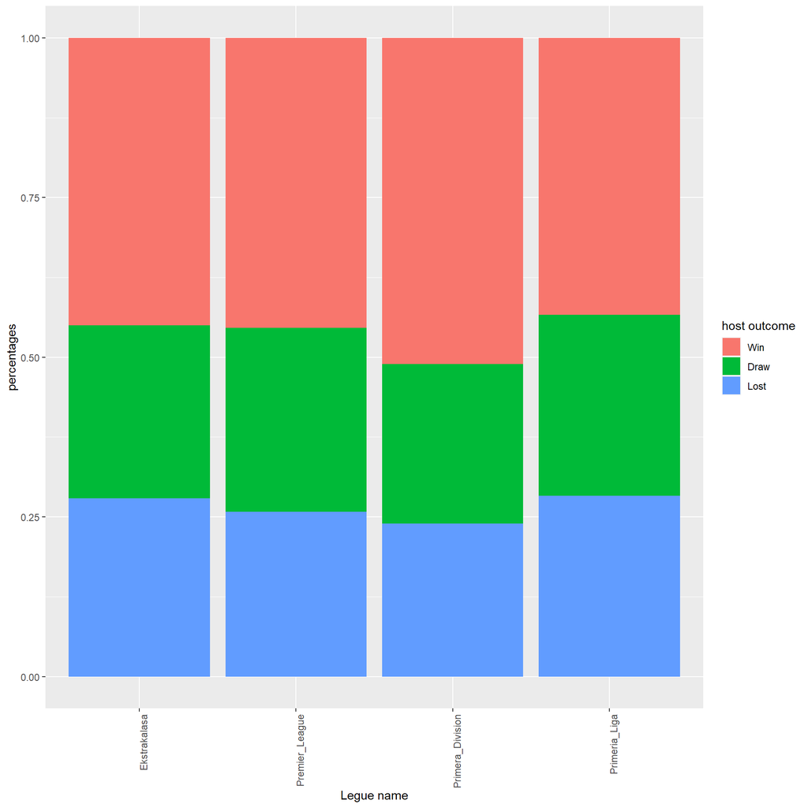

```r
library(ggplot2)

df = cbind(fc_data[1], fc_data[,2:4]/rowSums(fc_data[2:4]));

df <- data.frame(teams=rep(df[0],14),
       melt(df, id.vars=c("Name")))

ggplot(data=df, aes(x=Name,y=value,fill=as.factor(variable))) +
  geom_bar(position="fill",stat="identity") +
  theme(axis.text.x = element_text(angle=90, hjust=1)) +
  xlab("Legue name") +
  ylab("percentages") +
  scale_fill_discrete(name = "host outcome")
```

Wartość krytyczna $c$ będzie wyznaczana następującym wzorem:
$$c = F^{-1}_{\chi^{2}_{(n-1)(m-1)}}(1-\alpha)$$
Gdzie $n$, $m$ oznacza liczbę stopni swobody kolejno w wierszach i kolumnach. Poziom istotności wynosi: $\alpha = 0.05$

Dla danych danych liczba stopni swobody wyniosi 6:

```r
chi_freedom_degrees <- (dim(fc_data[,2:4])[1] - 1)*(dim(fc_data[,2:4])[2] - 1)
chi_freedom_degrees
```

```
## [1] 6
```

Wartość krytyczna natomiast:

```r
alpha <- 0.05
c <- qchisq(p=alpha, df=chi_freedom_degrees, lower.tail=FALSE)
```

$$c = F^{-1}_{\chi^{2}_{6}}(1-0,05) = 12.5915872$$
Następnie obliczam wartość $\chi^{2}$:

```r
col_sum <- matrix(colSums(fc_data[,2:4]))
row_sum <- matrix(rowSums(fc_data[,2:4]))

stat <- row_sum %*% t(col_sum)/sum(row_sum)

chisq <- sum((stat - fc_data[,2:4]) * (stat - fc_data[,2:4])/stat)
```

Wartość $\chi^{2}$ jest równa:
$$\chi^{2} = 4.7778437$$

Jest ona mniejsza niż wartość krytyczna, nie można więc odrzucić hipotezy zerowej.

Wyliczam p-wartość:

```r
p_val <- pchisq(chisq, df=chi_freedom_degrees, lower.tail=FALSE)
```

P-wartość wynosi:
$$p = 0.5726058$$

Jest ona większa niż poziom istotności $\alpha = 0.05$. Potwierdza to, że nie można odrzucić hipotezy zerowej.

Uzyskane wyniki zostają sprawdzone z funkcją $chisq.test$.

```r
chisq_test <- chisq.test(fc_data[2:4])
chisq_test
```

```
##
##  Pearson's Chi-squared test
##
## data:  fc_data[2:4]
## X-squared = 4.7778, df = 6, p-value = 0.5726
```

Takie same wyniki potwierdzają poprawność obliczeń.